# Il previsore ottimo

# Esercizio

Siano $X, \space Z$ variabili casuali normali standard **indipendenti**.

Sia $Y =|X|+Z$, calcolare:

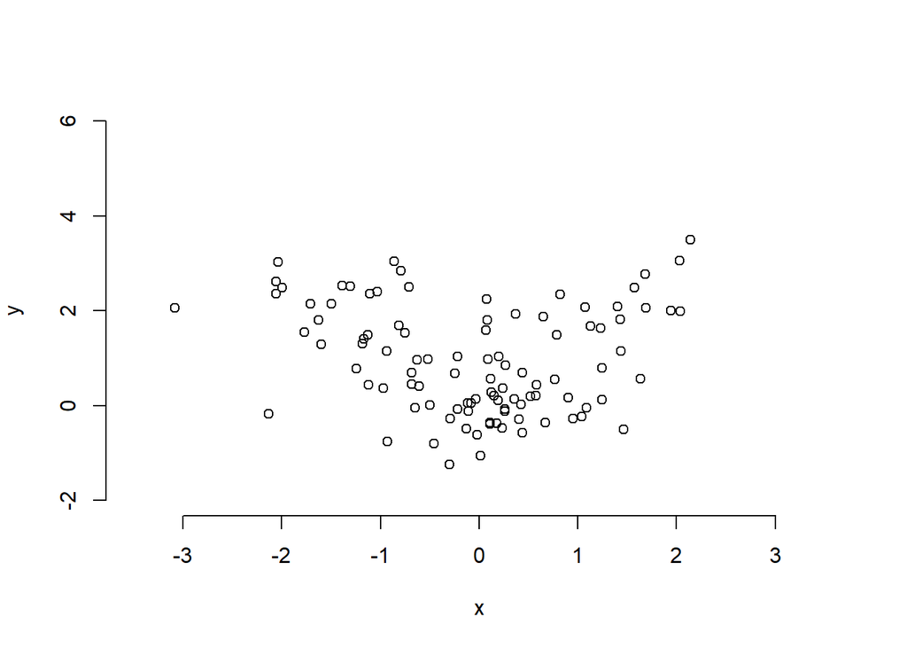

1. il previsore ottimo $E[Y|X]$ e il rispettivo MSE,
2. il previsore lineare $P[Y|X]$ e il rispettivo MSE,
3. il previsore lineare $P[Y|X^2]$ e il rispettivo MSE.

$$N.B. \\ E[|X|]=\sqrt{2/\pi}, \\ Var(|X|)=1- 2 / \pi \\ Cov(|X|,X^2)=\sqrt{2/ \pi}$$

Sia $Y = X \space Z^2$, calcolare:

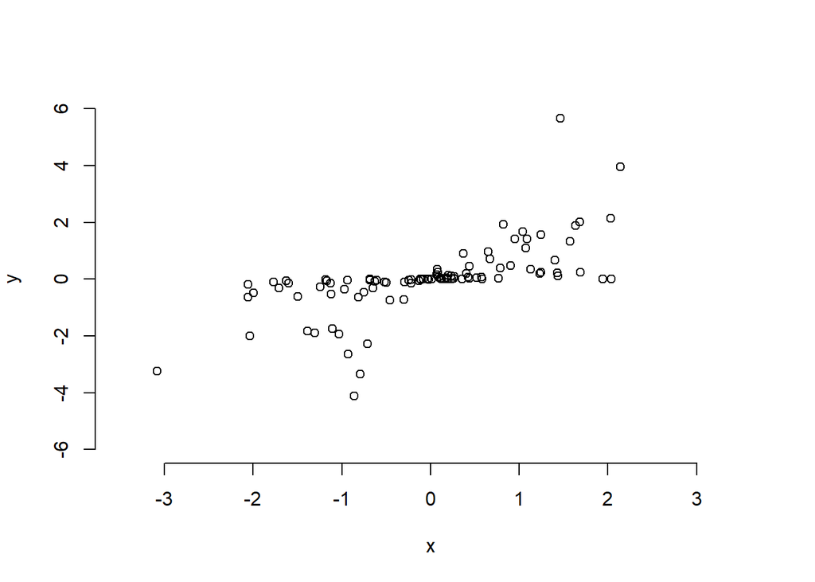

d. il previsore ottimo $E[Y|X]$ e il rispettivo MSE,  
e. il previsore ottimo $E[Y|X,Z]$ e il rispettivo MSE,  
f. il previsore lineare $P[Y|X]$ e il rispettivo MSE,  
g. il previsore lineare $P[Y|X,Z]$ e il rispettivo MSE.

## Soluzione

Domanda a.

$$i. \\ E[Y|X]=E[(|X|+Z)|X]=E[(|X|)|X]+E[Z|X]=|X| \\ ii. \\ MSE=E[(Y-|X|)^2]=E[(|X|+Z-|X|)^2]=E[Z^2]=Var(Z)=1$$

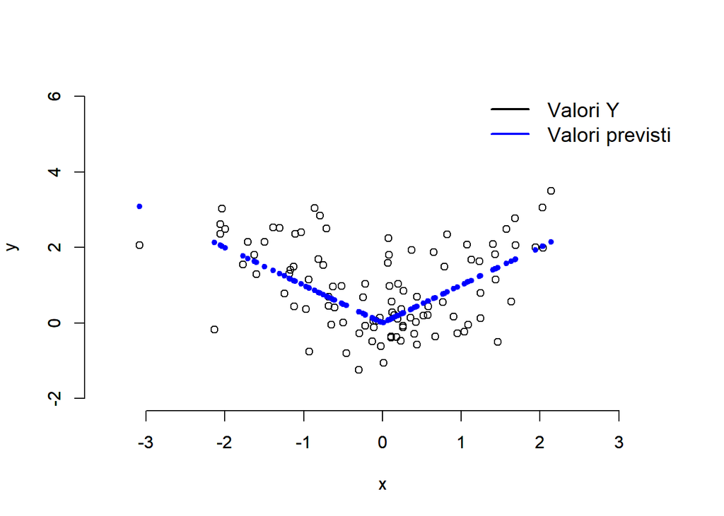

Domanda b.

$$i. \\ \mu_Y=E[Y]=E[(|X|+Z)]=E[(|X|)]+E[(Z)]= \sqrt{2/\pi} + 0 = \sqrt{2/\pi} \\\Sigma_{YX}= E[YX]-E[Y]E[X]=E[(|X|+Z)X]-E[(|X|+Z)]E[X]=\\=E[(|X|X)]+E[ZX]-(E[|X|]+E[Z])E[X] = \\=P(x<0)E[(X^2)]-P(x<0)E[(X^2)]+E[ZX]-(E[|X|]+E[Z])E[X] = \\ = 0.5 \space 0-0.5 \space 0 + 0 -(\sqrt{2/\pi}+0) \space 0=0 \\ non \space calcoliamo \space il \space resto \\ P(Y|X)=\sqrt{2/\pi} \approx 0.798, \\ ii. \\ MSE=E[(Y-\sqrt{2/\pi})^2]=E[(|X|-\sqrt{2/\pi}+Z)^2] = \\ = E[(|X|-\sqrt{2/\pi})^2]+E[Z^2]+2 E[(|X|-\sqrt{2/\pi})] E[Z] = \\ = E[(|X|-\sqrt{2/\pi})^2]+E[Z^2]= \\ = Var(|X|)+1 = 1- 2 / \pi +1 \approx 1.36$$

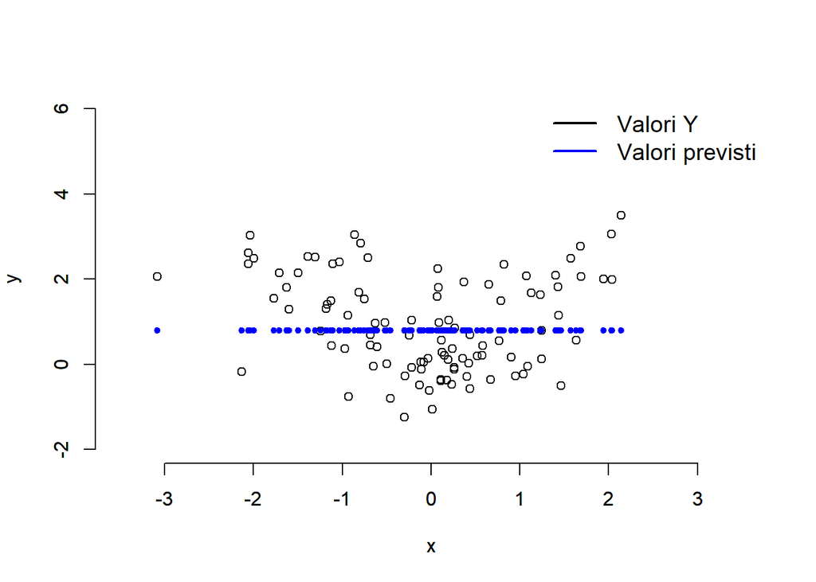

Domanda c.